# Tiger Software – Direct Mail Optimization Model

## **Project Overview**

Tiger Software is a technology company offering business productivity and analytics software to corporate customers. In this project, I develop an end-to-end data mining workflow to support customer targeting decisions by predicting purchase likelihood and spending among purchasers, then combining both to estimate *expected revenue* and quantify targeting lift and profit impact.

Data source: Tiger Software customer dataset (Tiger.xlsx) ; Tools: RStudio (caret)

```r
data <- read_excel("Tiger.xlsx", sheet = 2)
```

Download project files: 📥 Tiger.xlsx | 📥 TigerSoftware_Project_DuongThai.rmd

### **Results**

```r
# Regularized Linear Regression (Ridge/Lasso)
set.seed(42)
model_lm <- train(Spending ~ ., data = train_purch, method = "glmnet",
                  trControl = ctrl_reg, metric = "RMSE", preProcess = c("center", "scale"))


# Regression Tree
set.seed(42)
model_tree <- train(Spending ~ ., data = train_purch, method = "rpart",
                    trControl = ctrl_reg, metric = "RMSE")
# Neural Network
set.seed(42)
model_nnet <- train(Spending ~ ., data = train_purch, method = "nnet",
                    trControl = ctrl_reg, metric = "RMSE", preProcess = c("center", "scale"), trace = FALSE, linout = TRUE)

# Ensemble: Gradient Boosting
set.seed(42)
model_gbm <- train(Spending ~ ., data = train_purch, method = "gbm",
                   trControl = ctrl_reg, metric = "RMSE", verbose = FALSE)

# Evaluate models on test set
reg_models <- list(Linear = model_lm, Tree = model_tree, NNet = model_nnet, GBM = model_gbm)

reg_results <- lapply(reg_models, function(mod) {
  preds <- predict(mod, newdata = test_purch)
  rmse <- sqrt(mean((preds - test_purch$Spending)^2))
  mae <- mean(abs(preds - test_purch$Spending))
  c(RMSE = rmse, MAE = mae)
})

reg_results_df <- do.call(rbind, reg_results)
print(reg_results_df)
```

```
##            RMSE       MAE
## Linear 161.3811  97.45563
## Tree   178.6721 104.77517
## NNet   169.7479 101.62973
## GBM    153.4250  91.77626
```

Based on the estimated generalization error, the Gradient Boosting Machine (GBM) model is the best choice. It has the lowest Root Mean Squared Error (RMSE) at 153.43 and the lowest Mean Absolute Error (MAE) at 91.78 among all the models evaluated. These metrics indicate that GBM has the highest prediction accuracy and is likely to generalize better to unseen data compared to the Linear, Tree, and Neural Network (NNet) models. Therefore, GBM is the most suitable model for making reliable predictions in this context.

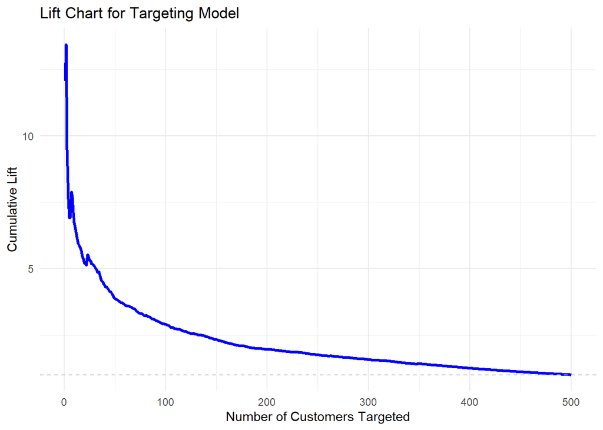

```r
# Copy of the test partition
score_data <- test_data

# Score using classification model (GBM): predicted probability of purchase
score_data$Purchase <- factor(ifelse(score_data$Purchase == 1, "Yes", "No"), levels = c("No", "Yes"))
score_data$pred_prob_purchase <- predict(model_gbm_1, newdata = score_data, type = "prob")[, "Yes"]

# Score using regression model (GBM): predicted spending
score_data$pred_spending <- predict(model_gbm, newdata = score_data)

# Add actual spending
score_data$actual_spending <- data_full$Spending[data_full$Partition == "s"]
score_data <- score_data %>%
  select(pred_prob_purchase, pred_spending, actual_spending, everything())

# Adjust probability of purchase for oversampling
score_data <- score_data %>%
  mutate(adjusted_prob = pred_prob_purchase * 0.107)

# Compute expected spending
score_data <- score_data %>%
  mutate(expected_spending = adjusted_prob * pred_spending)

# Sort by expected spending
score_data <- score_data %>%
  arrange(desc(expected_spending)) %>%
  mutate(rank = row_number())

# Compute cumulative actual spending and cumulative average spending
avg_spending_per_cust <- sum(score_data$actual_spending, na.rm = TRUE) / nrow(score_data)


score_data <- score_data %>%
  mutate(cum_actual_spending = cumsum(actual_spending),
         cum_random_spending = rank * avg_spending_per_cust,
         lift = cum_actual_spending / cum_random_spending)

# lot the Lift Chart
ggplot(score_data, aes(x = rank)) +
  geom_line(aes(y = lift), color = "blue", size = 1.2) +
  geom_hline(yintercept = 1, linetype = "dashed", color = "gray") +
  labs(title = "Lift Chart for Targeting Model",
       x = "Number of Customers Targeted",
       y = "Cumulative Lift") +
  theme_minimal()
```

Random Selection Given: 180,000 names (prospective customers)

Each catalog costs 2 dollars

Test partition of 500 customers had total spending of 46,951

So, average spending per customer: 46951/500 = 93.902

If I randomly select 180,000 customers, expected revenue: 180000 × 93.902 =16,902,360

Subtract Mailing Costs: Catalog costs: 180000×2=360,000

Estimated Gross Profit (Random): 16,902,360−360,000=16,542,360

If the firm were to randomly select 180,000 prospective customers from the pool, based on the average spending observed in the test data (approximately 93.90 per customer), the expected revenue would be 16,902,360. After accounting for mailing costs of 360,000, the estimated gross profit would be 16,542,360.

#### **Business Impact: Gross Profit from Model-Based Targeting**

From the lift chart, find the lift value at the targeting proportion:

180,000 customers out of a population of 5 million: 180000/5000000 = 0.036 or 3.6%

The test set has 500 rows, so target the top: 500 * 0.036 = 18 customers

From the score_data, get the lift at rank 18:

```r
score_data$lift[18]
```

```
## [1] 5.479076
```

Multiply lift (5.479076) by random revenue: ExpectedRevenue:

180000 * 93.902 * 5.479076 = 92,609,315

GrossProfit: 92,609,315 − 360,000 = 92,249,315

Comment on the Modeling Effort: By using the data mining model to prioritize prospective customers, the firm more than doubles its gross profit compared to random selection. This clearly demonstrates the value of predictive modeling in improving marketing efficiency and maximizing return on investment.

- ← Back to Portfolio